# QK Box 10.11

Van der Geest et al (2020) set up a field experiment to examine the mutualistic relationship between seagrasses (*Zostera noltei*) and lucinid bivalves (*Loripes orbiculatus*), in particular the extent to which the bivalves and their endosymbiotic bacteria could oxidize harmful sulfides and prevent their accumulation by seagrasses. In a coastal lagoon in the western Mediterranean, they established two fixed factors: presence or absence of bivalves (added vs control/background levels) and organic matter (added to increase pore water sulfide production vs control), with a single experimental plot for each combination replicated across six randomly chosen locations (blocks). The response variable we will analyze was the percentage of sulfur in plant tissue originating from the sediment (F_Sulfide).

You can find an image of the seagrass *Zostera noltei* here, but if you just would like to see what a typical Zostera looks like, here’s *Zostera nigricaulis* from southern Australia.

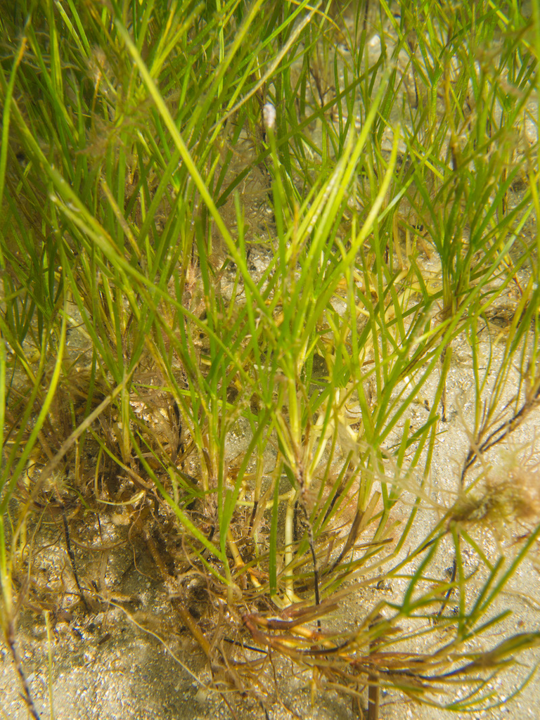

Mick Keough, [CC BY 4.0](https://creativecommons.org/licenses/by-sa/4.0)

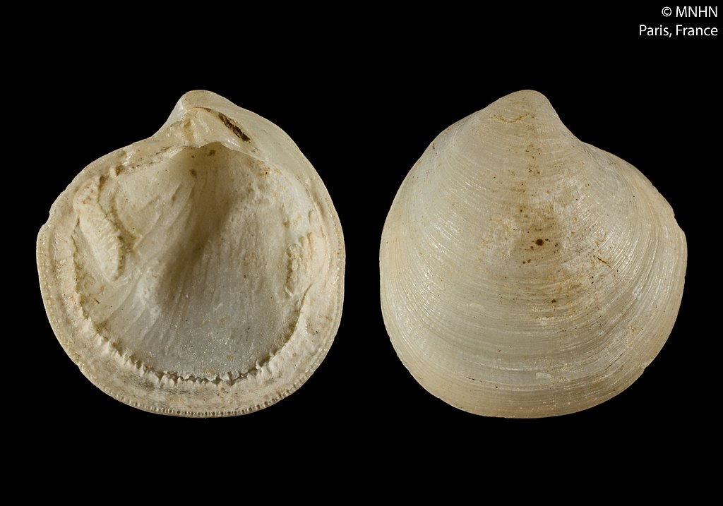

Lucinid bivalve, in this case *Loripes aberrans*. Muséum national d’histoire naturelle, [CC BY 4.0](https://creativecommons.org/licenses/by-sa/4.0)

### Preliminaries

First, load the required packages (afex, car, lattice, lme4, lmerTest, MuMin, nlme, VCA, emmeans)

Import vandergeest data file (vandergeest.csv)

```r
vandergeest <- read.csv("../data/vandergeest.csv")
vandergeest
```

| block | om | bivalve | fsulfide |
| --- | --- | --- | --- |
| B1 | C | C | 19.83133 |
| B1 | C | Added | 21.03708 |
| B1 | OM | C | 27.33173 |
| B1 | OM | Added | 22.18404 |
| B2 | C | C | 16.07735 |
| B2 | C | Added | 18.51201 |
| B2 | OM | C | 27.03725 |
| B2 | OM | Added | 23.13485 |
| B3 | C | C | 24.48036 |
| B3 | C | Added | 19.08550 |

[output cut: 14 more lines]

set contrasts from afex

```r
set_sum_contrasts()
```

```
## setting contr.sum globally: options(contrasts=c('contr.sum', 'contr.poly'))
```

### Fit OLS anova model to check residuals

```r
vandergeest.aov <- aov(fsulfide~om+bivalve+block+om*bivalve+om*block+bivalve*block, data=vandergeest)
```

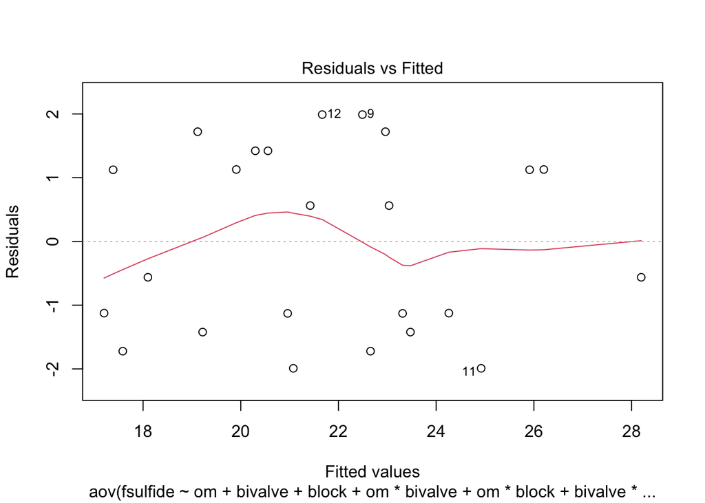

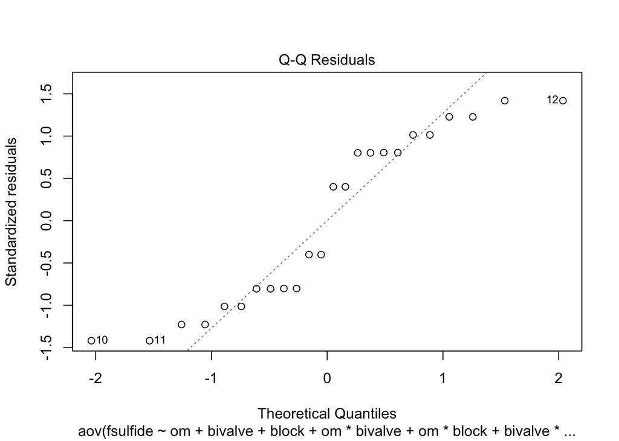

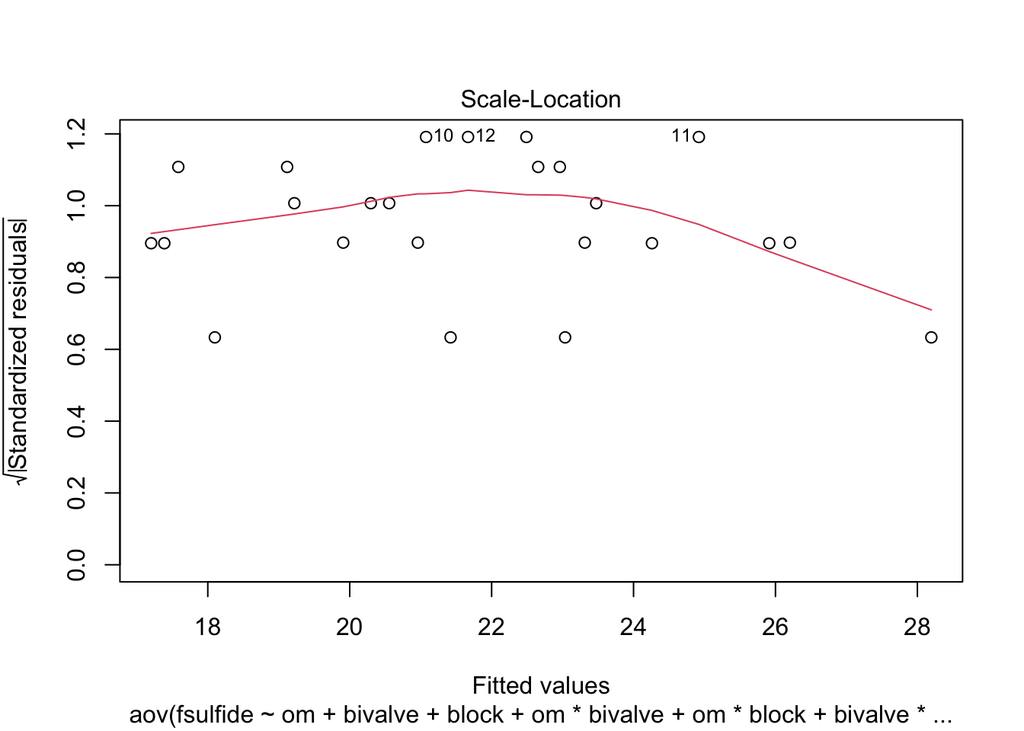

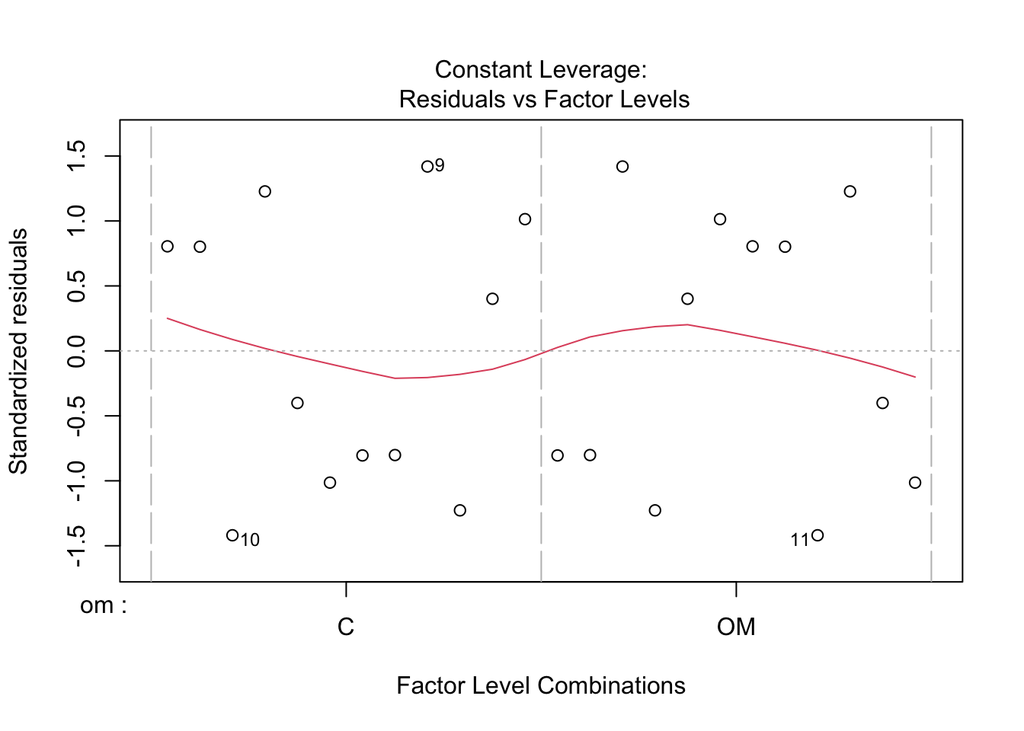

```r
plot(vandergeest.aov)
```

residuals look fine

### Fit models to get type III SS using car

```r
options(digits = 3)
vandergeest.lm <- lm(aov(fsulfide~om+bivalve+block+om*bivalve+om*block+bivalve*block, data=vandergeest))
Anova(vandergeest.lm, type='III')
```

|  | Sum Sq | Df | F value | Pr(>F) |
| --- | --- | --- | --- | --- |
| (Intercept) | 11350.05 | 1 | 1202.120 | 3.75e-07 |
| om | 100.71 | 1 | 10.667 | 2.23e-02 |
| bivalve | 25.12 | 1 | 2.661 | 1.64e-01 |
| block | 18.58 | 5 | 0.394 | 8.35e-01 |
| om:bivalve | 5.07 | 1 | 0.537 | 4.97e-01 |
| om:block | 23.93 | 5 | 0.507 | 7.63e-01 |
| bivalve:block | 23.40 | 5 | 0.496 | 7.70e-01 |
| Residuals | 47.21 | 5 | NA | NA |

Get correct F-ratio and P value for om: F = 100.711/4.785. These are the mean squares for om and om*block

```r
1-pf(100.711/4.785, 1, 5, lower.tail = TRUE, log.p = FALSE)
```

```
## [1] 0.00591
```

Get correct F-ratio and P value for bivalve 25.122/4.681

```r
1-pf(25.122/4.681, 1, 5, lower.tail = TRUE, log.p = FALSE)
```

```
## [1] 0.0683
```

Get main effect means

```r
emmeans(aov(fsulfide~om+bivalve+block+om*bivalve+om*block+bivalve*block, data=vandergeest), "om")
```

```
## NOTE: Results may be misleading due to involvement in interactions
```

```
##  om emmean    SE df lower.CL upper.CL
##  C    19.7 0.887  5     17.4     22.0
##  OM   23.8 0.887  5     21.5     26.1
##
## Results are averaged over the levels of: bivalve, block
## Confidence level used: 0.95
```

```r
emmeans(aov(fsulfide~om+bivalve+block+om*bivalve+om*block+bivalve*block, data=vandergeest), "bivalve")
```

```
## NOTE: Results may be misleading due to involvement in interactions
```

```
##  bivalve emmean    SE df lower.CL upper.CL
##  Added     20.7 0.887  5     18.4       23
##  C         22.8 0.887  5     20.5       25
##
## Results are averaged over the levels of: om, block
## Confidence level used: 0.95
```

#### Using VCA package to get anova var comps

```r
vandergeest.vca <- anovaMM(fsulfide~om+bivalve+om*bivalve + (block) + (om*block) + (bivalve*block) , vandergeest)
```

```
## Convert variable block from "character" to "factor"!
```

```
## Convert variable bivalve from "character" to "factor"!
```

```
## Convert variable om from "character" to "factor"!
```

```r
VCAinference(vandergeest.vca, alpha=0.05, VarVC=TRUE, excludeNeg=FALSE, constrainCI=FALSE)
```

```
##
##
##
## Inference from Mixed Model Fit
## ------------------------------
##
## > VCA Result:
## -------------
##
##  [Fixed Effects]
##
##               int               omC              omOM      bivalveAdded
##             25.28             -5.02              0.00             -2.97
##          bivalveC  omC:bivalveAdded omOM:bivalveAdded      omC:bivalveC
##              0.00              1.84              0.00              0.00
##     omOM:bivalveC
##              0.00
##
##
##  [Variance Components]
##
##   Name          DF      SS      MS     VC      %Total  SD     CV[%]   Var(VC)
## 1 total         19.5352                10.3647 100     3.2194 14.8042 3.694
## 2 block         5       18.5806 3.7161 0.923   8.9052  0.9607 4.4178  3.694
## 3 om:block      5       23.9258 4.7852 0*      0*      0*     0*      11.2043
## 4 bivalve:block 5       23.4033 4.6807 0*      0*      0*     0*      11.1054
## 5 error         5       47.2085 9.4417 9.4417  91.0948 3.0727 14.1297 35.6582
##
## Mean: 21.7 (N = 24)
##
## Experimental Design: balanced  |  Method: ANOVA | * VC set to 0 | adapted MS used for total DF
##
##
## > VC:
## -----
##               Estimate CI LCL CI UCL  One-Sided LCL One-Sided UCL
## total         10.3647  6.0336 21.838  6.5691        19.2672
## block         0.923    0*     4.69    0*            4.0844
## om:block      0        0*     6.5606  0*            5.5058
## bivalve:block 0        0*     6.5315  0*            5.4814
```

[output cut: 8 more lines]

```
## bivalve:block 0        0*     2.5557 0*            2.3412
## error         3.0727   1.918  7.5362 2.065         6.4197
##
## > CV[%]:
## --------
##               Estimate CI LCL  CI UCL  One-Sided LCL One-Sided UCL
## total         14.8042  11.2952 21.4889 11.7858       20.1844
## block         4.4178   0*      9.9585  0*            9.2933
## om:block      0        0*      11.7782 0*            10.7899
## bivalve:block 0        0*      11.7521 0*            10.766
## error         14.1297  8.8198  34.6546 9.4958        29.5205
##
##
## 95% Confidence Level  | * CI-limits constrained to be >= 0
## SAS PROC MIXED method used for computing CIs
```

## Fit mixed effects model using REML

```r
vandergeest.lmer1 <- lmer(fsulfide~om+bivalve+om*bivalve + (1|block) + (1|om:block)
                     + (1|bivalve:block) , REML=TRUE, vandergeest)
```

```
## boundary (singular) fit: see help('isSingular')
```

```r
summary(vandergeest.lmer1, ddf="Kenward-Roger")
```

```
## Linear mixed model fit by REML. t-tests use Kenward-Roger's method [
## lmerModLmerTest]
## Formula:
## fsulfide ~ om + bivalve + om * bivalve + (1 | block) + (1 | om:block) +
##     (1 | bivalve:block)
##    Data: vandergeest
##
## REML criterion at convergence: 104
##
## Scaled residuals:
##    Min     1Q Median     3Q    Max
## -1.850 -0.567 -0.096  0.723  1.774
##
## Random effects:
##  Groups        Name        Variance Std.Dev.
##  bivalve:block (Intercept) 0.00     0.00
##  om:block      (Intercept) 0.00     0.00
##  block         (Intercept) 0.00     0.00
##  Residual                  5.66     2.38
## Number of obs: 24, groups:  bivalve:block, 12; om:block, 12; block, 6
##
## Fixed effects:
##              Estimate Std. Error     df t value Pr(>|t|)
## (Intercept)    21.747      0.485  5.000   44.80    1e-07 ***
## om1            -2.048      0.485  5.000   -4.22   0.0083 **
## bivalve1       -1.023      0.485  5.000   -2.11   0.0889 .
## om1:bivalve1    0.460      0.485  5.000    0.95   0.3872
## ---
## Signif. codes:  0 '***' 0.001 '**' 0.01 '*' 0.05 '.' 0.1 ' ' 1
##
## Correlation of Fixed Effects:
##             (Intr) om1   bivlv1
## om1         0.000
## bivalve1    0.000  0.000
## om1:bivalv1 0.000  0.000 0.000
## optimizer (nloptwrap) convergence code: 0 (OK)
## boundary (singular) fit: see help('isSingular')
```

```r
anova(vandergeest.lmer1, ddf="Kenward-Roger")
```

|  | Sum Sq | Mean Sq | NumDF | DenDF | F value | Pr(>F) |
| --- | --- | --- | --- | --- | --- | --- |
| om | 100.71 | 100.71 | 1 | 5 | 17.806 | 0.00833 |
| bivalve | 25.12 | 25.12 | 1 | 5 | 4.442 | 0.08890 |
| om:bivalve | 5.07 | 5.07 | 1 | 5 | 0.897 | 0.38715 |

### Refit without 2-way interactions to solve singularity - unsuccessful

```r
vandergeest.lmer2 <- lmer(fsulfide~om+bivalve+om*bivalve + (1|block), REML=TRUE, vandergeest)
```

```
## boundary (singular) fit: see help('isSingular')
```

```r
summary(vandergeest.lmer2, ddf="Kenward-Roger")
```

```
## Linear mixed model fit by REML. t-tests use Kenward-Roger's method [
## lmerModLmerTest]
## Formula: fsulfide ~ om + bivalve + om * bivalve + (1 | block)
##    Data: vandergeest
##
## REML criterion at convergence: 104
##
## Scaled residuals:
##    Min     1Q Median     3Q    Max
## -1.850 -0.567 -0.096  0.723  1.774
##
## Random effects:
##  Groups   Name        Variance Std.Dev.
##  block    (Intercept) 0.00     0.00
##  Residual             5.66     2.38
## Number of obs: 24, groups:  block, 6
##
## Fixed effects:
##              Estimate Std. Error     df t value Pr(>|t|)
## (Intercept)    21.747      0.485  5.000   44.80    1e-07 ***
## om1            -2.048      0.485 15.000   -4.22  0.00074 ***
## bivalve1       -1.023      0.485 15.000   -2.11  0.05231 .
## om1:bivalve1    0.460      0.485 15.000    0.95  0.35867
## ---
## Signif. codes:  0 '***' 0.001 '**' 0.01 '*' 0.05 '.' 0.1 ' ' 1
##
## Correlation of Fixed Effects:
##             (Intr) om1   bivlv1
## om1         0.000
## bivalve1    0.000  0.000
## om1:bivalv1 0.000  0.000 0.000
## optimizer (nloptwrap) convergence code: 0 (OK)
## boundary (singular) fit: see help('isSingular')
```

```r
anova(vandergeest.lmer2, ddf="Kenward-Roger")
```

|  | Sum Sq | Mean Sq | NumDF | DenDF | F value | Pr(>F) |
| --- | --- | --- | --- | --- | --- | --- |
| om | 100.71 | 100.71 | 1 | 15 | 17.806 | 0.000743 |
| bivalve | 25.12 | 25.12 | 1 | 15 | 4.442 | 0.052306 |
| om:bivalve | 5.07 | 5.07 | 1 | 15 | 0.897 | 0.358674 |